# Ozone_regression_simple

Losseni SANGARE

2023-12-09

#REGRESSION SIMPLE Avec OZONE.txt

```r
rm(list = ls())
```

##Chargement du fichier

```r
ozone <- read.csv("D:/UTT/PROGRAMATION R/Data/ozone.txt", sep="")
View(ozone)
```

##quelques statistiques descriptives

```r
summary(ozone)
```

```
##      maxO3              T9             T12             T15
##  Min.   : 42.00   Min.   :11.30   Min.   :14.00   Min.   :14.90
##  1st Qu.: 70.75   1st Qu.:16.20   1st Qu.:18.60   1st Qu.:19.27
##  Median : 81.50   Median :17.80   Median :20.55   Median :22.05
##  Mean   : 90.30   Mean   :18.36   Mean   :21.53   Mean   :22.63
##  3rd Qu.:106.00   3rd Qu.:19.93   3rd Qu.:23.55   3rd Qu.:25.40
##  Max.   :166.00   Max.   :27.00   Max.   :33.50   Max.   :35.50
##       Ne9             Ne12            Ne15           Vx9
##  Min.   :0.000   Min.   :0.000   Min.   :0.00   Min.   :-7.8785
##  1st Qu.:3.000   1st Qu.:4.000   1st Qu.:3.00   1st Qu.:-3.2765
##  Median :6.000   Median :5.000   Median :5.00   Median :-0.8660
##  Mean   :4.929   Mean   :5.018   Mean   :4.83   Mean   :-1.2143
##  3rd Qu.:7.000   3rd Qu.:7.000   3rd Qu.:7.00   3rd Qu.: 0.6946
##  Max.   :8.000   Max.   :8.000   Max.   :8.00   Max.   : 5.1962
##       Vx12             Vx15            maxO3v           vent
##  Min.   :-7.878   Min.   :-9.000   Min.   : 42.00   Length:112
##  1st Qu.:-3.565   1st Qu.:-3.939   1st Qu.: 71.00   Class :character
##  Median :-1.879   Median :-1.550   Median : 82.50   Mode  :character
##  Mean   :-1.611   Mean   :-1.691   Mean   : 90.57
##  3rd Qu.: 0.000   3rd Qu.: 0.000   3rd Qu.:106.00
##  Max.   : 6.578   Max.   : 5.000   Max.   :166.00
##     pluie
##  Length:112
##  Class :character
##  Mode  :character
##
##
##
```

```r
str(ozone)
```

```
## 'data.frame':    112 obs. of  13 variables:
##  $ maxO3 : int  87 82 92 114 94 80 79 79 101 106 ...
##  $ T9    : num  15.6 17 15.3 16.2 17.4 17.7 16.8 14.9 16.1 18.3 ...
##  $ T12   : num  18.5 18.4 17.6 19.7 20.5 19.8 15.6 17.5 19.6 21.9 ...
##  $ T15   : num  18.4 17.7 19.5 22.5 20.4 18.3 14.9 18.9 21.4 22.9 ...
##  $ Ne9   : int  4 5 2 1 8 6 7 5 2 5 ...
##  $ Ne12  : int  4 5 5 1 8 6 8 5 4 6 ...
##  $ Ne15  : int  8 7 4 0 7 7 8 4 4 8 ...
##  $ Vx9   : num  0.695 -4.33 2.954 0.985 -0.5 ...
##  $ Vx12  : num  -1.71 -4 1.879 0.347 -2.954 ...
##  $ Vx15  : num  -0.695 -3 0.521 -0.174 -4.33 ...
##  $ maxO3v: int  84 87 82 92 114 94 80 99 79 101 ...
##  $ vent  : chr  "Nord" "Nord" "Est" "Nord" ...
##  $ pluie : chr  "Sec" "Sec" "Sec" "Sec" ...
```

toute les variabbles sont numeric hormis la direction du vent et le types de pluie effectuons des transformations sur nos varible pluie et vent en les transformant en numerique afin de verifier les corrélation

```r
library(dplyr)
ozone = mutate(ozone, vent=case_when(vent == "Nord" ~ 1,
                                     vent=="Sud" ~ 2,
                                     vent=="Est" ~ 3,
                                     vent=="Ouest" ~ 4))
```

verifion les valeurs unique la varible pluie puis effectuons nos transformation

```r
unique(ozone$pluie)
```

```
## [1] "Sec"   "Pluie"
```

```r
ozone = mutate(ozone, pluie=case_when(pluie=="Sec" ~ 0,
                                     pluie=="Pluie" ~ 1))
```

Nous avons transformer la variable pluie en bouléen. 1 si pluie, 0 sinon

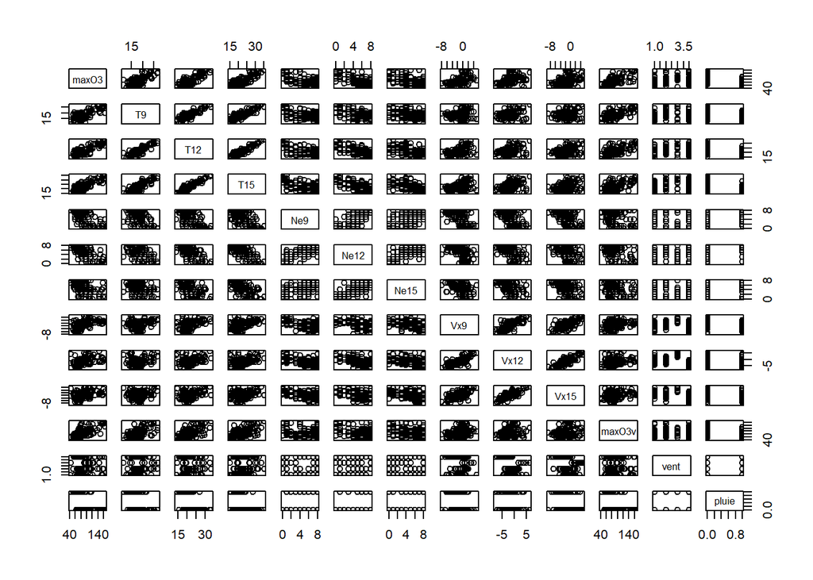

```r
pairs(ozone)
```

```r
cor(ozone)
```

```
##              maxO3          T9         T12         T15        Ne9       Ne12
## maxO3   1.00000000  0.69938654  0.78426233  0.77456998 -0.6217042 -0.6407513
## T9      0.69938654  1.00000000  0.88296716  0.84644601 -0.4838636 -0.4722475
## T12     0.78426233  0.88296716  1.00000000  0.94619304 -0.5842709 -0.6601002
## T15     0.77456998  0.84644601  0.94619304  1.00000000 -0.5861683 -0.6492261
## Ne9    -0.62170423 -0.48386362 -0.58427088 -0.58616833  1.0000000  0.7883411
## Ne12   -0.64075130 -0.47224753 -0.66010018 -0.64922610  0.7883411  1.0000000
## Ne15   -0.47830212 -0.32513861 -0.45809914 -0.57468170  0.5502490  0.7098668
## Vx9     0.52762341  0.25068965  0.43010447  0.45308919 -0.4976361 -0.4926581
## Vx12    0.43079585  0.22238575  0.31262905  0.34375057 -0.5287752 -0.5103204
## Vx15    0.39189889  0.17032155  0.27068023  0.28660283 -0.4939010 -0.4322695
## maxO3v  0.68451598  0.58224510  0.56362886  0.56788867 -0.2765500 -0.3619227
## vent   -0.06876898  0.01898871  0.03809549  0.03357149  0.2193930  0.2921112
## pluie  -0.47566681 -0.38332867 -0.44092818 -0.41511318  0.3913738  0.4221216
##              Ne15        Vx9       Vx12       Vx15      maxO3v        vent
## maxO3  -0.4783021  0.5276234  0.4307959  0.3918989  0.68451598 -0.06876898
## T9     -0.3251386  0.2506896  0.2223857  0.1703215  0.58224510  0.01898871
## T12    -0.4580991  0.4301045  0.3126291  0.2706802  0.56362886  0.03809549
## T15    -0.5746817  0.4530892  0.3437506  0.2866028  0.56788867  0.03357149
## Ne9     0.5502490 -0.4976361 -0.5287752 -0.4939010 -0.27654997  0.21939304
## Ne12    0.7098668 -0.4926581 -0.5103204 -0.4322695 -0.36192273  0.29211120
## Ne15    1.0000000 -0.4014717 -0.4318633 -0.3782896 -0.30847547  0.23142074
## Vx9    -0.4014717  1.0000000  0.7501775  0.6822608  0.34031716 -0.19860916
## Vx12   -0.4318633  0.7501775  1.0000000  0.8371720  0.22367549 -0.43310952
## Vx15   -0.3782896  0.6822608  0.8371720  1.0000000  0.18992198 -0.35699820
## maxO3v -0.3084755  0.3403172  0.2236755  0.1899220  1.00000000 -0.05404111
## vent    0.2314207 -0.1986092 -0.4331095 -0.3569982 -0.05404111  1.00000000
## pluie   0.2948889 -0.4249378 -0.2978510 -0.2059173 -0.37536770  0.19511781
##             pluie
## maxO3  -0.4756668
## T9     -0.3833287
## T12    -0.4409282
## T15    -0.4151132
## Ne9     0.3913738
## Ne12    0.4221216
## Ne15    0.2948889
## Vx9    -0.4249378
## Vx12   -0.2978510
## Vx15   -0.2059173
## maxO3v -0.3753677
## vent    0.1951178
## pluie   1.0000000
```

La concentration en ozone maxO3 est visiblement plus corrélé positivement à 78,42 % avec la température à 12h.

### Bien avant d’étudier la relation de max03 par rappor a T15, éffectuons le travail par rapport a T12

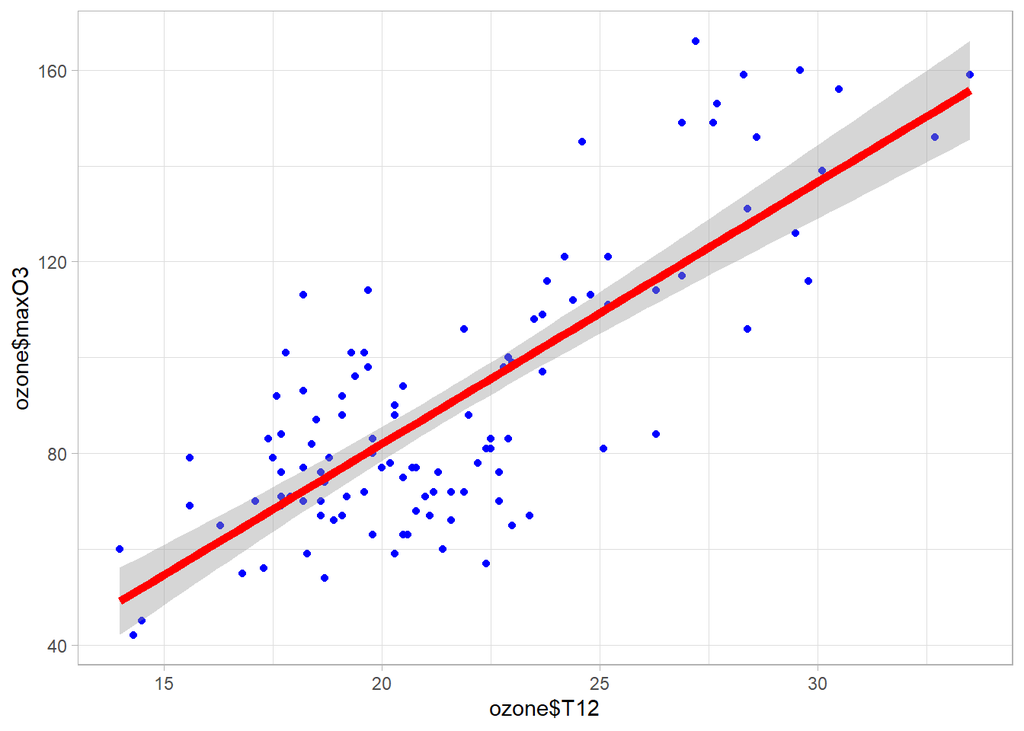

```r
library(ggplot2)
ggplot(ozone)+aes(x =ozone$T12,y = ozone$maxO3)+geom_point(color="blue")+ geom_smooth(method = "lm", color="red", lwd=2)+theme_light()
```

## Modélisation de maxo3 en fonction de T12

```r
rl = lm(ozone$maxO3 ~ ozone$T12)
summary(rl)
```

```
##
## Call:
## lm(formula = ozone$maxO3 ~ ozone$T12)
##
## Residuals:
##     Min      1Q  Median      3Q     Max
## -38.079 -12.735   0.257  11.003  44.671
##
## Coefficients:
##             Estimate Std. Error t value Pr(>|t|)
## (Intercept) -27.4196     9.0335  -3.035    0.003 **
## ozone$T12     5.4687     0.4125  13.258   <2e-16 ***
## ---
## Signif. codes:  0 '***' 0.001 '**' 0.01 '*' 0.05 '.' 0.1 ' ' 1
##
## Residual standard error: 17.57 on 110 degrees of freedom
## Multiple R-squared:  0.6151, Adjusted R-squared:  0.6116
## F-statistic: 175.8 on 1 and 110 DF,  p-value: < 2.2e-16
```

les coefficients estimés sont β0 = -27.4196 et β1 = 5.4687 avec des t value différent de 0

l’erreur standard de résidu qui une mesure de la précision du model est de 17,57 sur 110 dégré de liberté. R² nous montre que 61,51 % des données sont expliqués par le model, et avec un p-value inférieur à 5%.

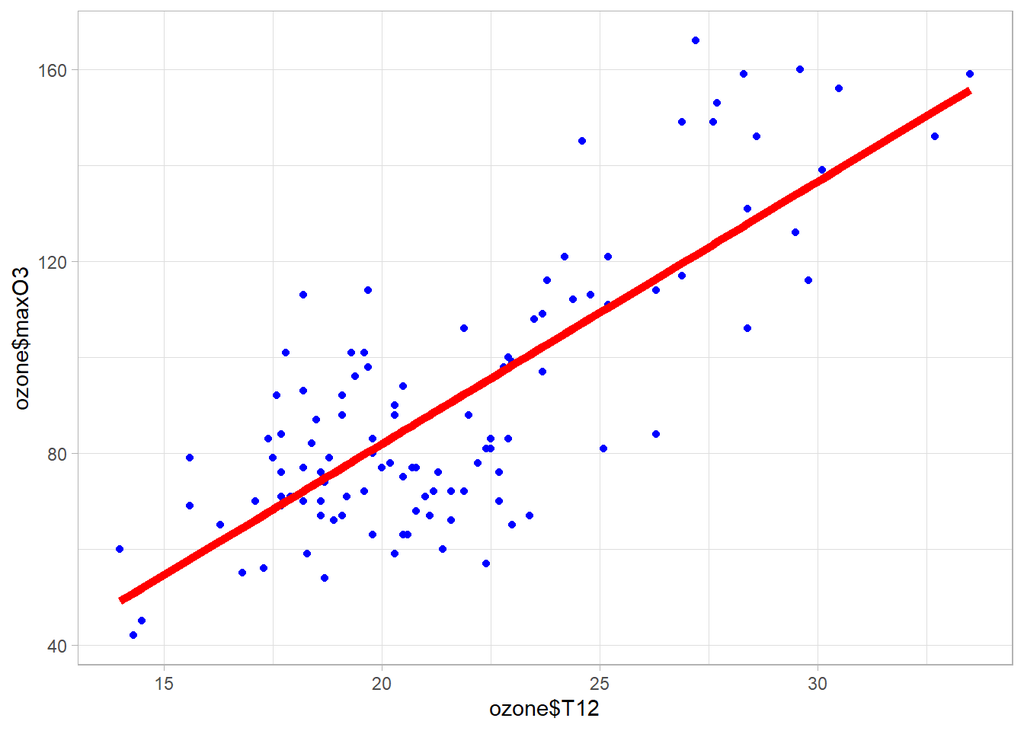

```r
pred = predict(rl, type = "response")
ggplot(ozone)+aes(x=ozone$T12,y=ozone$maxO3)+geom_point(color="blue")+geom_line(aes(y=pred),color="red",lwd=2)+theme_light()
```

### étudions maintenant la relation de max03 par rappor à T15

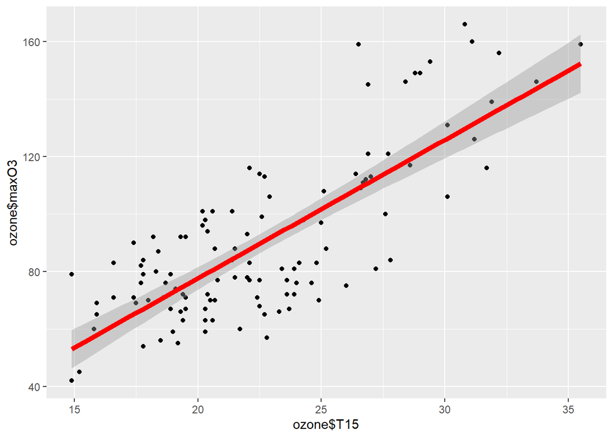

```r
ggplot(ozone)+aes(x = ozone$T15, y=ozone$maxO3)+geom_point()+geom_smooth(method ="lm",color="red",lwd=2)
```

##modelisation du model de regression linéaire simple de max03 en fonction de T15

```r
rl2 = lm(ozone$maxO3 ~ ozone$T15)
summary(rl2)
```

```
##
## Call:
## lm(formula = ozone$maxO3 ~ ozone$T15)
##
## Residuals:
##    Min     1Q Median     3Q    Max
## -34.13 -13.93   0.40  12.57  50.04
##
## Coefficients:
##             Estimate Std. Error t value Pr(>|t|)
## (Intercept) -18.7331     8.6562  -2.164   0.0326 *
## ozone$T15     4.8187     0.3752  12.844   <2e-16 ***
## ---
## Signif. codes:  0 '***' 0.001 '**' 0.01 '*' 0.05 '.' 0.1 ' ' 1
##
## Residual standard error: 17.91 on 110 degrees of freedom
## Multiple R-squared:    0.6,  Adjusted R-squared:  0.5963
## F-statistic:   165 on 1 and 110 DF,  p-value: < 2.2e-16
```

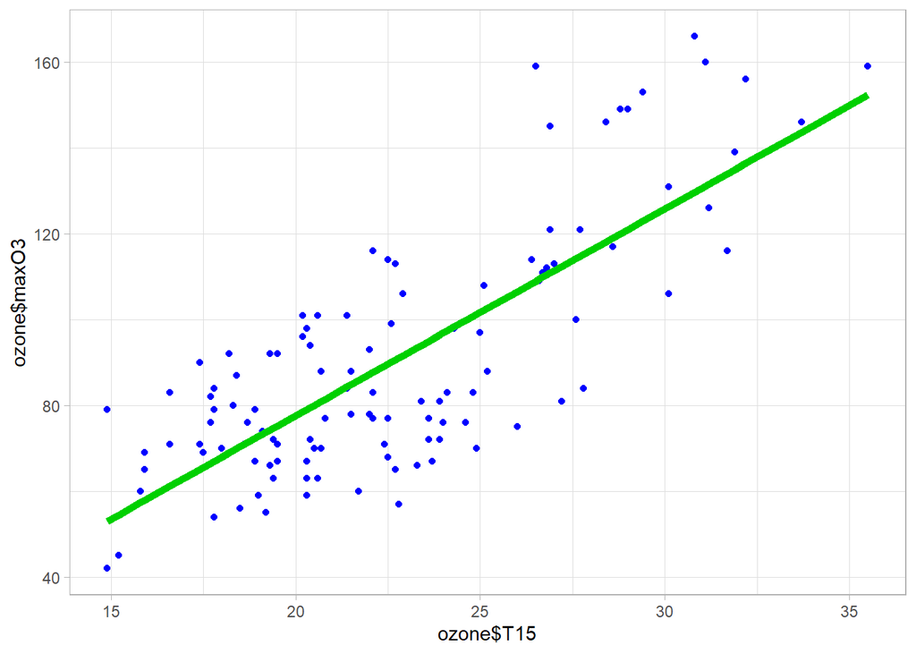

```r
pred2 = predict(rl2,type = "response")
ggplot(ozone)+aes(x=ozone$T15,y=ozone$maxO3)+geom_point(color="blue")+geom_line(aes(y=pred2), color="#00d000",lwd=2)+theme_light()
```